# Life and Time - PxVx - Bivariate Models

jflournoy

Mon Mar 14 16:02:42 2016

# Intro

**Template for model comparisons:**

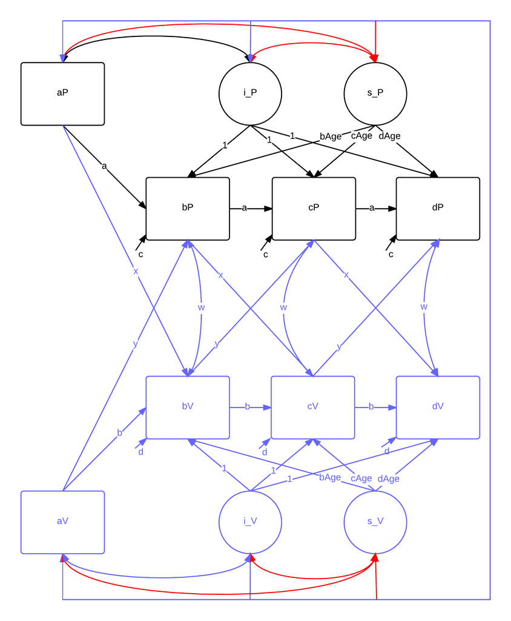

The above diagram captures all 4 possible models combinations. The black is the univariate ALT model, and the blue adds all paths we estimate for the bivariate ALT. Red paths show the paths constrained to be 0 in the mean-only (fixed slope) model. Letter labels indicate paths constrained to be equal.

## What are the best models that converge?

In the below figures, each bar represents the ‘model score’ of a model combination for a bivariate ALT model. A score of 2 indicates that there were no problems, 1 indicates that there were warnings about the standard error being computed (e.g., with MLF instead of MLR), and 0 indicates that there were errors (non-convergence).

The tables show the winning model giving preference to the full bivariate random slope ALT model, even if it was estimated with MLF instead of MLR (this is not very common in the national sample, but more so in the college sample).

The model for the personality variable comes first, so ‘Lin_MeanOnly’ means ‘full linear ALT model for personality variable, fixed mean slope ALT model for value variable.’

### National

| pVar | aspfin | BFA_MT | HRZ_COL | HRZ_IND | MVS_mc | USI | VRT_COL | VRT_IND |
| --- | --- | --- | --- | --- | --- | --- | --- | --- |
| BFA_AC | Lin_Lin | Lin_Lin | Lin_Lin | Lin_Lin | Lin_Lin | Lin_Lin | Lin_Lin | Lin_Lin |
| BFA_AP | Lin_Lin | Lin_Lin | Lin_Lin | Lin_Lin | Lin_Lin | Lin_Lin | Lin_Lin | Lin_Lin |
| BFA_CI | Lin_Lin | Lin_Lin | Lin_Lin | Lin_Lin | Lin_Lin | Lin_Lin | Lin_Lin | Lin_Lin |
| BFA_CO | Lin_Lin | Lin_Lin | Lin_Lin | Lin_Lin | Lin_Lin | Lin_Lin | Lin_Lin | Lin_Lin |
| BFA_EA | Lin_Lin | Lin_Lin | Lin_Lin | Lin_Lin | Lin_Lin | Lin_Lin | Lin_Lin | Lin_Lin |
| BFA_EE | Lin_Lin | Lin_Lin | Lin_Lin | Lin_Lin | Lin_Lin | Lin_Lin | Lin_Lin | Lin_Lin |
| BFA_NV | Lin_Lin | Lin_Lin | Lin_Lin | Lin_Lin | Lin_Lin | Lin_Lin | Lin_Lin | Lin_Lin |
| BFA_NW | Lin_Lin | Lin_Lin | Lin_Lin | Lin_Lin | Lin_Lin | Lin_Lin | Lin_Lin | Lin_Lin |
| BFA_OI | Lin_Lin | Lin_Lin | Lin_Lin | Lin_Lin | Lin_Lin | Lin_Lin | Lin_Lin | Lin_Lin |
| BFA_OO | Lin_Lin | Lin_Lin | Lin_Lin | Lin_Lin | Lin_Lin | Lin_Lin | Lin_Lin | Lin_Lin |
| BFI_A6 | Lin_Lin | Lin_Lin | Lin_Lin | Lin_Lin | Lin_Lin | Lin_Lin | Lin_Lin | Lin_Lin |
| BFI_C | Lin_Lin | Lin_Lin | Lin_Lin | Lin_Lin | Lin_Lin | Lin_Lin | Lin_Lin | Lin_Lin |
| BFI_E | Lin_Lin | Lin_Lin | Lin_Lin | Lin_Lin | Lin_Lin | Lin_Lin | Lin_Lin | Lin_Lin |
| bfi_hp8 | Lin_Lin | Lin_Lin | Lin_Lin | Lin_Lin | Lin_Lin | Lin_Lin | Lin_Lin | Lin_Lin |
| BFI_N | Lin_Lin | Lin_Lin | Lin_Lin | Lin_Lin | Lin_Lin | Lin_Lin | Lin_Lin | Lin_Lin |
| BFI_O | Lin_Lin | Lin_Lin | Lin_Lin | Lin_Lin | Lin_Lin | Lin_Lin | Lin_Lin | Lin_Lin |
| D_SCALE | Lin_Lin | Lin_Lin | Lin_Lin | Lin_Lin | Lin_Lin | Lin_Lin | Lin_Lin | Lin_Lin |
| I_A | Lin_Lin | Lin_Lin | Lin_Lin | Lin_Lin | Lin_Lin | Lin_Lin | Lin_Lin | Lin_Lin |
| I_C | Lin_Lin | Lin_Lin | Lin_Lin | Lin_Lin | Lin_MeanOnly | Lin_Lin | Lin_Lin | Lin_Lin |
| I_D | Lin_Lin | Lin_Lin | Lin_Lin | Lin_Lin | Lin_Lin | Lin_Lin | Lin_Lin | Lin_Lin |
| I_E | Lin_Lin | Lin_Lin | Lin_Lin | Lin_Lin | Lin_MeanOnly | Lin_Lin | Lin_Lin | Lin_Lin |
| I_N | Lin_Lin | Lin_Lin | Lin_Lin | Lin_Lin | Lin_MeanOnly | Lin_Lin | Lin_Lin | Lin_Lin |
| I_O | Lin_Lin | Lin_Lin | Lin_Lin | Lin_Lin | Lin_MeanOnly | Lin_Lin | Lin_Lin | Lin_Lin |
| I_S | Lin_Lin | Lin_Lin | Lin_Lin | Lin_Lin | Lin_Lin | Lin_Lin | Lin_Lin | Lin_Lin |
| S_SCALE | Lin_Lin | Lin_Lin | Lin_Lin | Lin_Lin | Lin_Lin | Lin_Lin | Lin_Lin | Lin_Lin |

[figure not shown]

National Sample

### College

| pVar | aspfin | BFA_MT | HRZ_COL | HRZ_IND | MVS_mc | USI | VRT_COL | VRT_IND |
| --- | --- | --- | --- | --- | --- | --- | --- | --- |
| BFA_AC | Lin_Lin | Lin_Lin | Lin_Lin | Lin_Lin | Lin_Lin | Lin_Lin | Lin_Lin | Lin_Lin |
| BFA_AP | Lin_Lin | Lin_Lin | Lin_Lin | Lin_Lin | Lin_Lin | Lin_Lin | Lin_Lin | Lin_Lin |
| BFA_CI | Lin_Lin | Lin_Lin | Lin_Lin | Lin_Lin | MeanOnly_Lin | Lin_Lin | Lin_Lin | Lin_Lin |
| BFA_CO | Lin_Lin | Lin_Lin | Lin_Lin | Lin_Lin | Lin_Lin | Lin_Lin | Lin_Lin | Lin_MeanOnly MeanOnly_Lin |
| BFA_EA | Lin_Lin | Lin_Lin | Lin_Lin | Lin_Lin | Lin_Lin | Lin_Lin | Lin_Lin | Lin_Lin |
| BFA_EE | Lin_Lin | Lin_Lin | Lin_Lin | Lin_Lin | Lin_MeanOnly MeanOnly_Lin | Lin_Lin | Lin_Lin | Lin_Lin |
| BFA_NV | Lin_Lin | Lin_Lin | Lin_Lin | Lin_Lin | Lin_Lin | Lin_Lin | Lin_Lin | Lin_Lin |
| BFA_NW | Lin_Lin | Lin_Lin | Lin_Lin | Lin_Lin | Lin_MeanOnly MeanOnly_Lin | Lin_Lin | Lin_Lin | Lin_Lin |
| BFA_OI | Lin_Lin | Lin_Lin | Lin_Lin | Lin_Lin | Lin_MeanOnly MeanOnly_Lin | Lin_Lin | Lin_Lin | Lin_Lin |
| BFA_OO | Lin_Lin | Lin_Lin | Lin_Lin | Lin_Lin | Lin_Lin | Lin_Lin | Lin_Lin | Lin_Lin |
| BFI_A6 | Lin_Lin | Lin_Lin | Lin_Lin | Lin_Lin | Lin_MeanOnly MeanOnly_Lin | Lin_Lin | Lin_Lin | Lin_Lin |
| BFI_C | Lin_Lin | Lin_Lin | Lin_Lin | Lin_Lin | Lin_MeanOnly | Lin_Lin | Lin_Lin | Lin_Lin |
| BFI_E | Lin_Lin | Lin_Lin | Lin_Lin | Lin_Lin | Lin_MeanOnly | Lin_Lin | Lin_Lin | Lin_Lin |
| bfi_hp8 | Lin_Lin | Lin_Lin | Lin_Lin | Lin_Lin | Lin_Lin | Lin_Lin | Lin_Lin | Lin_Lin |
| BFI_N | Lin_Lin | Lin_Lin | Lin_Lin | Lin_Lin | Lin_Lin | Lin_Lin | Lin_Lin | Lin_MeanOnly MeanOnly_Lin |
| BFI_O | Lin_Lin | Lin_Lin | Lin_Lin | Lin_Lin | Lin_Lin | Lin_Lin | Lin_Lin | Lin_Lin |
| D_SCALE | Lin_Lin | Lin_Lin | Lin_Lin | Lin_Lin | Lin_Lin | Lin_Lin | Lin_Lin | Lin_Lin |
| S_SCALE | Lin_Lin | Lin_Lin | Lin_Lin | Lin_Lin | Lin_MeanOnly MeanOnly_Lin | Lin_Lin | Lin_Lin | Lin_Lin |

[figure not shown]

College Sample

## Non-Lin_Lin Models: Univariate best-fit

| sample | pVar | vVar | bestCombo | AIC_P | BIC_P | LL_P | AIC_V | BIC_V | LL_V |
| --- | --- | --- | --- | --- | --- | --- | --- | --- | --- |
| Col | BFA_CI | MVS_mc | MeanOnly_Lin | AR_Int | AR_Int | AR_Int | AR_Int | AR_Int | AR_Int |
| Col | BFA_CO | VRT_IND | Lin_MeanOnly MeanOnly_Lin | AR_Int | AR_Int | AR_Int | AR_Int | AR_Int | AR_Int |
| Col | BFA_EE | MVS_mc | Lin_MeanOnly MeanOnly_Lin | AR_Int | AR_Int | AR_Int | AR_Int | AR_Int | AR_Int |
| Col | BFA_NW | MVS_mc | Lin_MeanOnly MeanOnly_Lin | AR_Int | AR_Int | AR_Int | AR_Int | AR_Int | AR_Int |
| Col | BFA_OI | MVS_mc | Lin_MeanOnly MeanOnly_Lin | AR_LinM | AR_Int | AR_Int | AR_Int | AR_Int | AR_Int |
| Col | BFI_A6 | MVS_mc | Lin_MeanOnly MeanOnly_Lin | AR_LinM | AR_LinM | AR_LinM | AR_Int | AR_Int | AR_Int |
| Col | BFI_C | MVS_mc | Lin_MeanOnly | AR_Int | AR_Int | AR_Int | AR_Int | AR_Int | AR_Int |
| Col | BFI_E | MVS_mc | Lin_MeanOnly | AR_LinM | AR_Int | AR_Int | AR_Int | AR_Int | AR_Int |
| Col | BFI_N | VRT_IND | Lin_MeanOnly MeanOnly_Lin | AR_Int | AR_Int | AR_Int | AR_Int | AR_Int | AR_Int |
| Col | S_SCALE | MVS_mc | Lin_MeanOnly MeanOnly_Lin | AR_Lin | AR_Int | AR_Int | AR_Int | AR_Int | AR_Int |
| Nat | I_C | MVS_mc | Lin_MeanOnly | AR_LinM | AR_LinM | AR_LinM | AR_Lin | AR_Lin | AR_Lin |
| Nat | I_E | MVS_mc | Lin_MeanOnly | AR_LinM | AR_Int | AR_LinM | AR_Lin | AR_Lin | AR_Lin |
| Nat | I_N | MVS_mc | Lin_MeanOnly | AR_LinM | AR_Int | AR_LinM | AR_Lin | AR_Lin | AR_Lin |
| Nat | I_O | MVS_mc | Lin_MeanOnly | AR_Int | AR_Int | AR_Int | AR_Lin | AR_Lin | AR_Lin |

# Parameter plots

## National: AR paths across variable combinations and model types

[figure not shown]

## National: XL paths across variable combinations and model types

[figure not shown]

## College: AR paths across variable combinations and model types

[figure not shown]

## College: XL paths across variable combinations and model types

[figure not shown]